# An investigation into the modelling required to predict quality of exercise style based on data from quantified self movement devices.

John Snell

19 January 2016

## Executive Summary

This report examines the use of machine learning to predict the quality of a specific physical exercise - the performance of dumbbell lifts both (a) correctly and (b) incorrectly in 4 different ways. The raw data consists of input from sensors positioned at four key points - the forearm, the upper arm, the belt, and the barbell itself, for 6 test candidates. The data provided consisted of a training set (19622 records) of 160 variables including the activity classification of either acceptable exercise (A) or 4 modes of incorrect exercise (B:E) as a training set of data, and a testing set (20 records) also containing 160 variables except the classification variable was replaced in this set with a record id variable ranging 1:20. For this report, the training dataset was partitioned into a true training set (13081 records), and a validation set (6541 records). The training was performed using both random trees and gerenalised boosted regression as the modelling algorithms with boosting over 25 resamples and cross validation across 10 folds as the basis for the replacement algorithms. A total of 6 models were constructed. Predictions were made on the validation dataset for each model and confusion matrices derived, based on these predictions. The most accurate model was Model 2 showing an accuracy of 99.76% and out of sample error rate of 16 errors out of 6541 validation records (0.24%). As a result, this model was used to predict the outcomes of the 20 test records. These predictions were verified as correct for all 20 of the records in the formal testing dataset.

## Introduction

The data for this assignment was originated by Velloso et al. (2013) as part of their research working into using machine learning in order to determine and provide feedback to participants regarding the quality of a physical activity in which they are involved. The data was downloaded from their web site using [training data] https://d396qusza40orc.cloudfront.net/predmachlearn/pml-training.csv and [testing data] https://d396qusza40orc.cloudfront.net/predmachlearn/pml-testing.csv.

The activity defined for their research was one set of 10 repetitions of the Unilateral Dumbell Biceps Curl. Essentially the dataset is looking at the dynamics of 4 interconnected points (forearm, arm, belt, and dumbell) in space as the 6 participants work through each exercise mode: A - correcly, B - throwing the elbows to the front, C - lifting the dumbbbell only halfway ,D - lowering the dumbbell only halfway, and E - throwing the hips forward. We can consider the dynamics of the activities through the perspective of roll, pitch, and yaw which define the three rotational modes for any object in a 3D space. A change in any one of these rotational modes is experienced by the other 2 modes in a highly non-linear way. There is by necessity physical couplings between the arm, forearm, belt, and dumbbell. These couplings also have their own degrees of freedom which considerably exacerbates the overall non-linearity built into this system.

### Cleaning the dataset

Exploration of the testing dataset shows a large number of the variables in this dataset are of no significance in building a prediction model because either they are empty in the test set so cannot be used to classify the test records or are providing descriptive information such as the names of the participants performing the activity. As there is no intent at this stage to try and personalise the training such information provides no value in a predictive sense. All of these variables were discounted and only those variables that were actual measurements as made by the sensors were retained. This reduced the dataset from 160 to 53 variables. (See Table 2). The training dataset is large (19622 records) and was divided into a true training set consisting of two thirds of the records, with the other third being put into a validation set to allow the modelled parameters to be cross validated and the out of sample error and hence accuracy of the model fit to be determined.

### Exploratory Analysis of Dataset

In this intial explorations we intially isolated the roll, pitch and yaw for each sensor and performed preliminary plots on all 19622 records contained in the training dataset - see Figures 1 & 2. The plots of these variables against each other show distinct complex non-linear patterns of interactions indicating that a technique such as random forests should be used to train the detection system. Finally one of the rotational modes - *roll* - was chosen to see if any patterns could be determined when examining this mode across all four sensors - See Figure 3. Once again there are hints of behavioural patterns being expressed but the noise in the data makes it difficult to discern them by eye.

### Construction of Model

As the datasets require the prediction of a factor variable with 5 levels (the *classe* variable) of a highly compex and interactive system with considerable noise, two modelling methods were employed: (a) the random forest modelling method which has many advantages as detailed by Walker (2013):

- Accuracy
- Runs efficiently on large data bases
- Handles thousands of input variables without variable deletion
- Gives estimates of what variables are important in the classification
- Generates an internal unbiased estimate of the generalization error as the forest building progresses
- Provides effective methods for estimating missing data
- Maintains accuracy when a large proportion of the data are missing
- Provides methods for balancing error in class population unbalanced data sets
- Generated forests can be saved for future use on other data
- Prototypes are computed that give information about the relation between the variables and the classification.
- Computes proximities between pairs of cases that can be used in clustering, locating outliers, or (by scaling) give interesting views of the data
- Capabilities of the above can be extended to unlabelled data, leading to unsupervised clustering, data views and outlier detection
- Offers an experimental method for detecting variable interactions.

and (b) the generalized boosting method. The latter was chosen as a potential alternative to random forests which are computationally intensive. The notable cons of the random forest technique are:

- Speed - especially with such a large training set - model 1 took 5122 seconds to complete using 3 cores of a 4 core Intel I7 processor
- Tendency to overfit

Six models were constructed as part of this investigation on the basis of examining the impact of different modelling methods, different resampling techniques, and different numbers of records used to train the models.

### Cross Validation

Cross validation was specifically adressed by dividing the original training dataset into two parts, a formal training set and a validation set which was used to determine the accuracy and out of sample error for each of the models constructed.

Two models were specifically constructed which only differed in the nature of the resampling used - Model 1 and Model 2 (see Table 1). For Model 1, the default resampling algorithm of 25 iterations of bootstrapping was used. For the second model, a 10-fold cross validation resampling was used. The fit which provided the highest accuracy was used to classify the test dataset.

### Prediction

Each model was tested agains the 20 record testing dataset to see how many records could be correctly classified on the A-E scale. The results are available in Table 1. The output from the most accurate model (Model 2) was used to verify the results of the test set against the course quiz. Each model test output was then verified agins the output from Model 2.

### Results

Table 1: Results obtained from using 6 different models to predict outcomes from a test dataset

[output not shown]

#### Explanation of columns in results table

- Training: The regression technique used to train the model
- Replacement: The replacement technique used to cross validate the process
- Records: Number of records used to train the model
- Time: The time in seconds required to train the model using 3 cores of a 4 core Intel I7 processor
- Errors: The number of records incorrectly classified in the validation set
- OOSE: Out of Sample Error estimate
- Test: Number of test records correctly identified
- Probability: The probability of classifying all 20 test records correctly

## Appendices

### Appendix A Figures

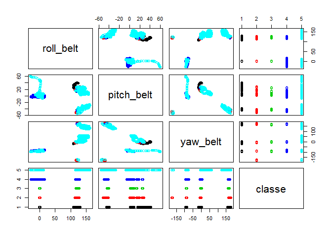

Figure 1: Detecting patterns in the roll, pitch, and yaw of the belt sensor

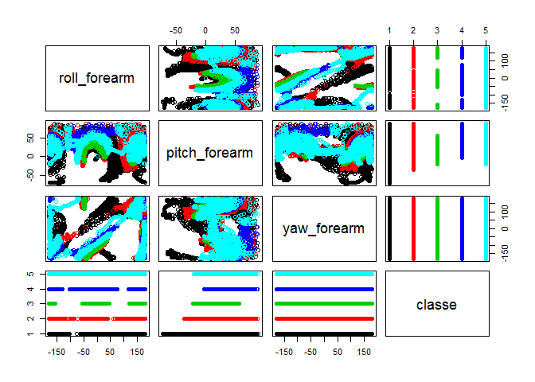

Figure 2: Detecting patterns in the roll, pitch, and yaw of the forearm sensor

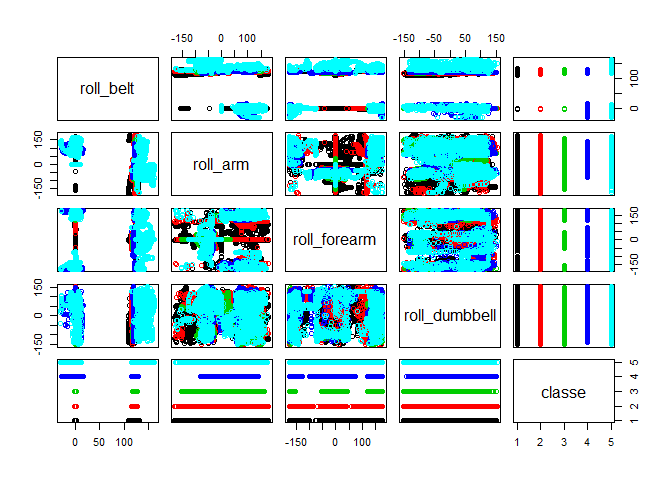

Figure 3: Detecting patterns in the roll for the sensors in each of the 4 positions

### Appendix B Tables

Table 2: An examination of the variables in the cleaned training dataset

| variable.name | type | missing | distinct.values | precision | min | max |
| --- | --- | --- | --- | --- | --- | --- |
| roll_belt | numeric | 0 | 1330 | 1e-02 | -28.9 | 162 |
| pitch_belt | numeric | 0 | 1840 | 1e-02 | -55.8 | 60.3 |
| yaw_belt | numeric | 0 | 1957 | 1e-02 | -180 | 179 |
| total_accel_belt | numeric | 0 | 29 | 1e+00 | 0 | 29 |
| gyros_belt_x | numeric | 0 | 140 | 1e-02 | -1.04 | 2.22 |
| gyros_belt_y | numeric | 0 | 69 | 1e-02 | -0.64 | 0.64 |
| gyros_belt_z | numeric | 0 | 169 | 1e-02 | -1.46 | 1.62 |
| accel_belt_x | numeric | 0 | 164 | 1e+00 | -120 | 85 |
| accel_belt_y | numeric | 0 | 143 | 1e+00 | -69 | 164 |
| accel_belt_z | numeric | 0 | 299 | 1e+00 | -275 | 105 |
| magnet_belt_x | numeric | 0 | 327 | 1e+00 | -52 | 485 |
| magnet_belt_y | numeric | 0 | 298 | 1e+00 | 354 | 673 |
| magnet_belt_z | numeric | 0 | 457 | 1e+00 | -623 | 293 |
| roll_arm | numeric | 0 | 2654 | 1e-02 | -180 | 180 |
| pitch_arm | numeric | 0 | 3087 | 1e-02 | -88.8 | 88.5 |
| yaw_arm | numeric | 0 | 2876 | 1e-02 | -180 | 180 |
| total_accel_arm | numeric | 0 | 66 | 1e+00 | 1 | 66 |
| gyros_arm_x | numeric | 0 | 643 | 1e-02 | -6.37 | 4.87 |
| gyros_arm_y | numeric | 0 | 376 | 1e-02 | -3.44 | 2.84 |
| gyros_arm_z | numeric | 0 | 248 | 1e-02 | -2.33 | 3.02 |
| accel_arm_x | numeric | 0 | 777 | 1e+00 | -404 | 437 |
| accel_arm_y | numeric | 0 | 537 | 1e+00 | -318 | 308 |
| accel_arm_z | numeric | 0 | 792 | 1e+00 | -636 | 292 |
| magnet_arm_x | numeric | 0 | 1339 | 1e+00 | -584 | 782 |
| magnet_arm_y | numeric | 0 | 872 | 1e+00 | -392 | 583 |
| magnet_arm_z | numeric | 0 | 1265 | 1e+00 | -597 | 694 |
| roll_dumbbell | numeric | 0 | 16523 | 0e+00 | -153.7137292 | 153.5455708 |
| pitch_dumbbell | numeric | 0 | 16040 | 0e+00 | -149.5936479 | 149.4024436 |
| yaw_dumbbell | numeric | 0 | 16381 | 0e+00 | -150.8711542 | 154.9522941 |
| total_accel_dumbbell | numeric | 0 | 43 | 1e+00 | 0 | 58 |
| gyros_dumbbell_x | numeric | 0 | 241 | 1e-02 | -204 | 2.22 |
| gyros_dumbbell_y | numeric | 0 | 278 | 1e-02 | -2.1 | 52 |
| gyros_dumbbell_z | numeric | 0 | 206 | 1e-02 | -2.38 | 317 |
| accel_dumbbell_x | numeric | 0 | 425 | 1e+00 | -419 | 235 |
| accel_dumbbell_y | numeric | 0 | 466 | 1e+00 | -189 | 315 |
| accel_dumbbell_z | numeric | 0 | 410 | 1e+00 | -334 | 318 |
| magnet_dumbbell_x | numeric | 0 | 1128 | 1e+00 | -643 | 592 |
| magnet_dumbbell_y | numeric | 0 | 844 | 1e+00 | -3600 | 633 |
| magnet_dumbbell_z | numeric | 0 | 676 | 1e-01 | -262 | 452 |
| roll_forearm | numeric | 0 | 2176 | 1e-02 | -180 | 180 |
| pitch_forearm | numeric | 0 | 2915 | 1e-02 | -72.5 | 89.8 |
| yaw_forearm | numeric | 0 | 1991 | 1e-02 | -180 | 180 |
| total_accel_forearm | numeric | 0 | 70 | 1e+00 | 0 | 108 |
| gyros_forearm_x | numeric | 0 | 298 | 1e-02 | -22 | 3.97 |
| gyros_forearm_y | numeric | 0 | 741 | 1e-02 | -7.02 | 311 |
| gyros_forearm_z | numeric | 0 | 307 | 1e-02 | -8.09 | 231 |
| accel_forearm_x | numeric | 0 | 794 | 1e+00 | -498 | 477 |
| accel_forearm_y | numeric | 0 | 1003 | 1e+00 | -632 | 923 |
| accel_forearm_z | numeric | 0 | 580 | 1e+00 | -446 | 291 |
| magnet_forearm_x | numeric | 0 | 1524 | 1e+00 | -1280 | 672 |
| magnet_forearm_y | numeric | 0 | 1872 | 1e-03 | -896 | 1480 |
| magnet_forearm_z | numeric | 0 | 1683 | 1e-04 | -973 | 1090 |
| classe | pure factor | 0 | 5 | NA | A | E |

### Appendix C Code

```r
#read data
setwd("~/RStudio/Practical Machine Learning/Assignment")
tr<-read.csv("https://d396qusza40orc.cloudfront.net/predmachlearn/pml-training.csv")
tst<-read.csv("https://d396qusza40orc.cloudfront.net/predmachlearn/pml-testing.csv")

#extract variables to use for training and testing
tr1<-tr[c(8:11,37:49,60:68,84:86,102,113:124,140,151:160)]
testassignment<-tst[c(8:11,37:49,60:68,84:86,102,113:124,140,151:159)]

#examine variables in training and test datsets
whatis(tr1)
whatis(testassignment)

#construct some exploratory plots to look at dependency patterns of some variables
```

```r
#Construct model1
library(doParallel)
registerDoParallel(cores = 3)
set.seed(3454)

##use this code to build the intial model
#build a model fit using the random trees method and the boost/25 times
#technique for resampling the data
#saving the model once it has been built

# system.time(mod1<-train(classe~.,data=training1,method = "rf", prox=T))
# saveRDS(mod1,file="model1.rds")

#Use this code if model was previously built so read it in from file
mod1<-readRDS("model1.rds")

#predict the values of classe that should be established for the testing dataset
#check the prediction against the validation data by deriving the confusion matrix
```

```r
#Construct model2
#to check on the resampling algorithm, build a new model fit using a
#10 fold cross validations technique for resampling the data.
#saving the model once it has been built.

mod2<-readRDS("model2.rds")
#trC<-trainControl("cv",10)
#set.seed(3454)
#system.time(mod2<-train(classe~.,data=training1,method = "rf", trControl=trC, prox=T))
# saveRDS(mod2,file="model2.rds")
```

```r
#Construct model3

#to determine the impact of sample size repeat model 2 but using
#only half of the records in the training set,
#the validation set remains the same.
mod3<-readRDS("model3.rds")
#trC<-trainControl("cv",10)
#training3<-tr1[folds$Fold1,]
#set.seed(3454)
#system.time(mod3<-train(classe~.,data=training3, method = "rf", trControl=trC, prox=T))
#saveRDS(mod3,file="model3.rds")
```

```r
#Construct model4

temp<-tr1[folds$Fold1,]
subfolds<-createFolds(temp$classe,k=2)
training4<-temp[subfolds$Fold1,]
mod4<-readRDS("model4.rds")
#trC<-trainControl("cv",10)
#set.seed(3454)
#system.time(mod4<-train(classe~.,data=training4, method = "rf", trControl=trC, prox=T))
#saveRDS(mod4,file="model4.rds")
```

```r
#Construct model5
#using a different modelling method - generalized boosted regression
trC<-trainControl("cv",10)
set.seed(3454)
system.time(mod5<-train(classe~.,data=tr1[folds$Fold1,], method = "gbm", trControl=trC))
saveRDS(mod5,file="model5.rds")
```

```r
#Construct model6

#using a different modelling method - generalized boosted regression on a larger training set
trC<-trainControl("cv",10)
set.seed(3454)
system.time(mod6<-train(classe~.,data=training1, method = "gbm", trControl=trC))
saveRDS(mod6,file="model6.rds")
```

```r
#Validate models
pr1<-predict(mod1,newdata=testing1)
cf1<-confusionMatrix(pr1,testing1$classe)
#print out the confusion matriX for this model fit.
cf1

#use the model fit to determine the classe for each record of the test set
prassign1<-predict(mod1,newdata = testassignment)
prassign1

pr2<-predict(mod2,newdata=testing1)
cf2<-confusionMatrix(pr2,testing1$classe)
cf2

prassign2<-predict(mod2,newdata = testassignment)
prassign2

pr3<-predict(mod3,newdata=testing1)
cf3<-confusionMatrix(pr3,testing1$classe)
cf3
prassign3<-predict(mod3,newdata = testassignment)
prassign3

pr4<-predict(mod4,newdata=testing1)
cf4<-confusionMatrix(pr4,testing1$classe)
cf4
prassign4<-predict(mod4,newdata = testassignment)
prassign4

pr5<-predict(mod5,newdata=testing1)
cf5<-confusionMatrix(pr5,testing1$classe)
cf5

prassign5<-predict(mod5,newdata = testassignment)
prassign5

pr6<-predict(mod6,newdata=testing1)
cf6<-confusionMatrix(pr6,testing1$classe)
cf6

prassign6<-predict(mod6,newdata = testassignment)
prassign6

#Verify accuracy of models 1,3,4,5,6 against Model 2
mod1result<-prassign1==prassign2
mod3result<-prassign3==prassign2
mod4result<-prassign4==prassign2
mod5result<-prassign5==prassign2
mod6result<-prassign6==prassign2
```

```r
#build results table and store on disk
results<-matrix(NA,nrow=6,ncol=10)
results[,1]<-c(1,"random forest (rf)","boost 25", dim(training1)[1],5122,48,1-cf1$overall[1],cf1$overall[1],sum(mod1result),cf1$overall[1]^20)

Model<-1:6
Training<-c(rep('random forest (rf)',4),rep('cv/10',2))
Replacement<-c('boost/25',rep('cv/10',5))
Records<-c(rep(dim(training1)[1],2),dim(training3)[1],dim(training4)[1],dim(training3)[1],dim(training1)[1])
Time<-c(5122,1833,437,140,103,199)
Errors<-c(calculatValidationErrors(cf1),calculatValidationErrors(cf2),calculatValidationErrors(cf3),calculatValidationErrors(cf4),calculatValidationErrors(cf5),calculatValidationErrors(cf6))
OOSE<-c(round(1-cf1$overall[1],4),round(1-cf2$overall[1],4),round(1-cf3$overall[1],4),round(1-cf4$overall[1],4),round(1-cf5$overall[1],4),round(1-cf6$overall[1],4))
Accuracy<-c(round(cf1$overall[1],4),round(cf2$overall[1],4),round(cf3$overall[1],4),round(cf4$overall[1],4),round(cf5$overall[1],4),round(cf6$overall[1],4))
Test<-c(sum(mod1result),20,sum(mod3result),sum(mod4result),sum(mod5result),sum(mod6result))
Probability<-c(round(cf1$overall[1]^20,2),round(cf2$overall[1]^20,2),round(cf3$overall[1]^20,2),round(cf4$overall[1]^20,2),round(cf5$overall[1]^20,2),round(cf6$overall[1]^20,2))
results<-data.frame(Model,Training,Replacement,Records,Time,Errors,OOSE,Accuracy,Test,Probability)
write.csv(results,"Results.csv")

#function to calculate the total number of validation errors derived from the confusion matrix or each model
#parameter cf is the confusion matrix of the model being assessed
calculatValidationErrors<-function (cf){
  errors<-sum(sum(cf$table[,1])-cf$table[1,1],sum(cf$table[,2])-cf$table[2,2],sum(cf$table[,3])-cf$table[3,3],sum(cf$table[,4])-cf$table[4,4],sum(cf$table[,5])-cf$table[5,5])
  return(errors)
}
```

Bibliography

Velloso, E, A Bulling, H Gellersen, W Ugulino, and H Fuks. 2013. “Qualitative Activity Recognition of Weight Lifting Exercises.” In *Proceedings of 4th International Conference in Cooperation with SIGCHI (Augmented Human 13)*. Stuttgart , Germany: ACM SIGCHI.

Walker, M. 2013. “Random Forests Algorithm.” http://www.datasciencecentral.com/profiles/blogs/random-forests-algorithm.